# Identificando coordenadas com valores de países suspeitos

Nesse tutorial aprenderemos a identificar informações inconsistentes de países atribuídos e coordenadas de dados do **SpeciesLink** (https://specieslink.net/).

Como exemplo, usaremos os registros de Apocynaceae do Herbário da Universidade Estadual de Campinas (UEC).

### Instalação e carregamento dos pacotes

Vamos precisar de dois pacotes: **openxlsx**, para ler arquivos Excel e **raster**, para manusear formatos de arquivos SIG.

- **openxlsx** (Schauberger *et al*., 2020): https://ycphs.github.io/openxlsx/index.html
- **raster** (Hijmans *et al*., 2021): https://rspatial.org/raster

Instalamos os pacotes com o comando `install.packages()`:

```r
install.packages(c("openxlsx","raster"), repos="http //cran.us.r-project.org")
```

Carregamos os pacotes com o comando `library()`:

```r
library("openxlsx")
library("raster")
```

### Setup do ambiente de trabalho e carregamento dos dados

Vamos definir o diretório de trabalho, onde estarão a *planilha* baixada do **SpeciesLink** e o *shapefile* baixado do **NaturalEarth** (https://www.naturalearthdata.com/). Para isso, usamos a função `set.wd()`.

```r
setwd("/Users/jdvidal/Desktop/INCT/")
```

Vamos usar a função `read.xlsx()` para ler a planilha baixada do **SpeciesLink**.

```r
records <- read.xlsx("speciesLink-20210920072313-0004598.xlsx")
```

E a função `shapefile()` para ler o shapefile com os limites geográficos e nomes dos países do mundo. Este shapefile pode ser baixado diretamente do link a seguir:https://naturalearth.s3.amazonaws.com/10m_cultural/ne_10m_admin_0_countries.zip

```r
countries <- shapefile("ne_10m_admin_0_countries/ne_10m_admin_0_countries.shp")
```

### Inspeção e preparação dos dados

```r
head(records)
```

[output not shown]

[output cut: 64 more lines]

[output not shown]

Aqui temos nosso primeiro problema.

```r
class(records$latitude)
```

```
## [1] "character"
```

Os valores de coordenadas estão sendo interpretados como texto. Para convertê-los para números, usamos a função `as.numeric()`.

```r
records$latitude <- as.numeric(records$latitude)
records$longitude <- as.numeric(records$longitude)
```

Vamos nos certificar de usar apenas dados que possuam informação geográfica. Para isso, usamos `complete.cases()` para selecionar apenas linhas cujos valores estão completos para a coluna “latitude”.

```r
records <- records[complete.cases(records$latitude),]
```

Vamos verificar agora as informações de país nas entradas do SpeciesLink. Para isso, convertemos a coluna country para fatores com a função `as.factor()` e depois exibimos informações básicas sobre a coluna com a função `summary()`.

```r
records$country <- as.factor(records$country)
summary(records$country)
```

```
##  Argentina    Bolivia     Brazil   Colombia Costa Rica       Cuba    Ecuador
##          5         59       7226         15          2          2         14
##     Guyana     Mexico     Panama   Paraguay       Peru  Venezuela
##          1         13          2         16         28          2
```

Vamos agora converter o data.frame “records” para um objeto espacial. Para isso, usamos a função `coordinates()` e declaramos que as colunas “longitude” e “latitude” correspondem aos valores de coordenadas x e y.

```r
coordinates(records) <- ~longitude+latitude
```

### Extração de valores com base nos pontos geográficos

Vamos visualizar agora os pontos que temos no dataset. Para isso, plotamos o shapefile countries para a região de interesse (América do Sul). Declaramos como limites x e y (`xlim` e `ylim`) para o plot: -70o a -35o de longitude e -50 graus a 10 graus de latitude. E adicionamos os pontos com a função `points()`. Vamos plotar os pontos em vermelho (`col="red"`).

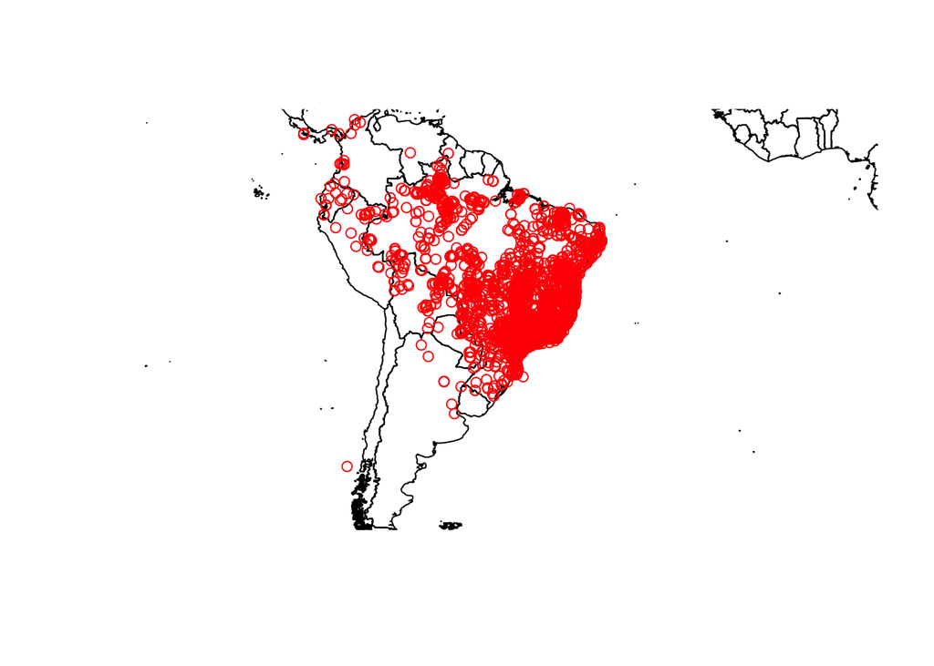

```r
plot(countries, xlim=c(-70,-35), ylim=c(-50,10))
points(records, col="red")
```

Vamos agora extrair os valores das localidades onde os pontos intersectam o shapefile. Para isso, usamos a função `intersect()`, que leva como argumentos dois objetos espaciais (os pontos e o shape) que se sobrepõe.

```r
extracted <- intersect(records, countries)
```

Convertemos agora o spatialDataFrame resultante para um data.frame comum com a função `as.data.frame()`.

```r
extracted <- as.data.frame(extracted)
```

### Execução do teste lógico e preparação do resultado

Os valores de país precisam ser reconvertidos para caracteres para podermos executar o teste lógico. Para converter, usamos a função `as.character()`.

```r
extracted$country <- as.character(extracted$country)
extracted$ADMIN <- as.character(extracted$ADMIN)
```

Agora usamos o teste lógico `extracted$country!=extracted$ADMIN` para retornar os índices onde os valores do campo country do SpeciesLink diferem dos valores de ADMIN do shapefile. Como queremos as linhas do data.frame onde as informações diferem, usamos a sintaxe “dataframe[x,]”, onde os colchetes indicam que queremos um subconjunto do dataframe original, e o x representa os índices que queremos. Como queremos todas as colunas, deixamos vazia a sequencia após a vírgula, assim obteremos todas as colunas.

```r
list_mismatches <- extracted[extracted$country!=extracted$ADMIN,]
```

### Visualização dos resultados

Vamos inspecionar quantos registros tiveram informações diferentes de países no SpeciesLink para os países aos quais a coordenada associada pertence com a função `nrow()`, que retorna o número de linhas de um data.frame.

```r
nrow(list_mismatches)
```

```
## [1] 19
```

Finalmente, vamos abrir a planilha com os outliers obtidos. Para isso, usamos a função `View()`.

```r
View(list_mismatches)
```